# Data preprocessing and Visualisaton for Poverty Dataset

#### PHONE AND INTERNET USAGE

There is a rapid raise in the phone ownership from age 17 to 33 and from age 33 to 69 the phone ownership rate has been decreased. Male use internet more compared to female. People in urban area have more internet access comapared to urban area. Those who have more number of phone ownership the more the internet usuage

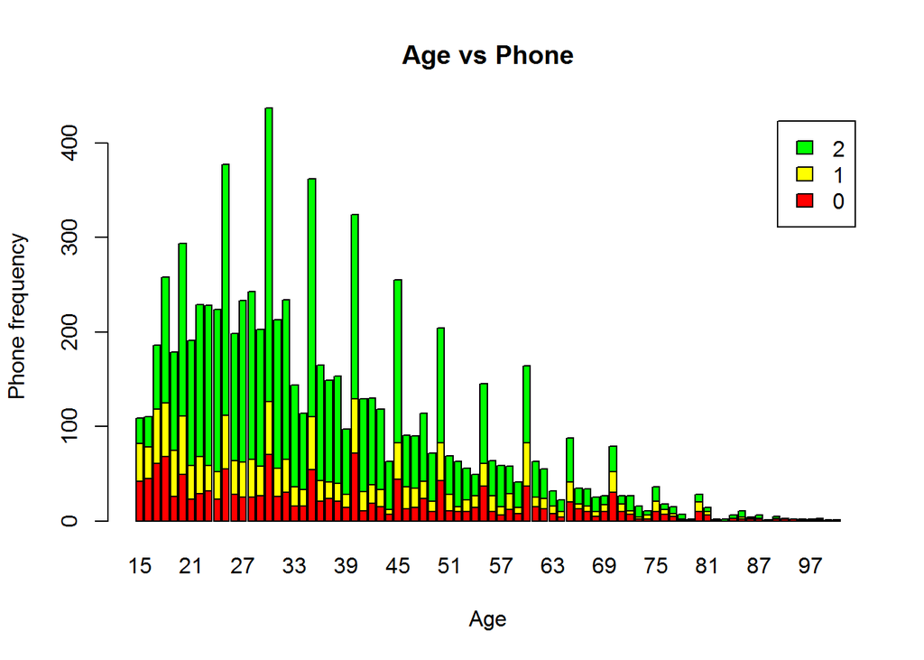

```r
#PhoneOwnership and age
counts<-table(phone_ownership,age)

barplot(counts,main="Age vs Phone",xlab="Age", ylab="Phone frequency",col=c("red", "yellow","green"),legend=rownames(counts))
```

```r
#Internet vs GENDER
inter<-table(can_use_internet,Gender)
inter
```

```
##                 Gender
## can_use_internet      female male
##            FALSE    0   3822 2563
##            TRUE     0    820 1195
```

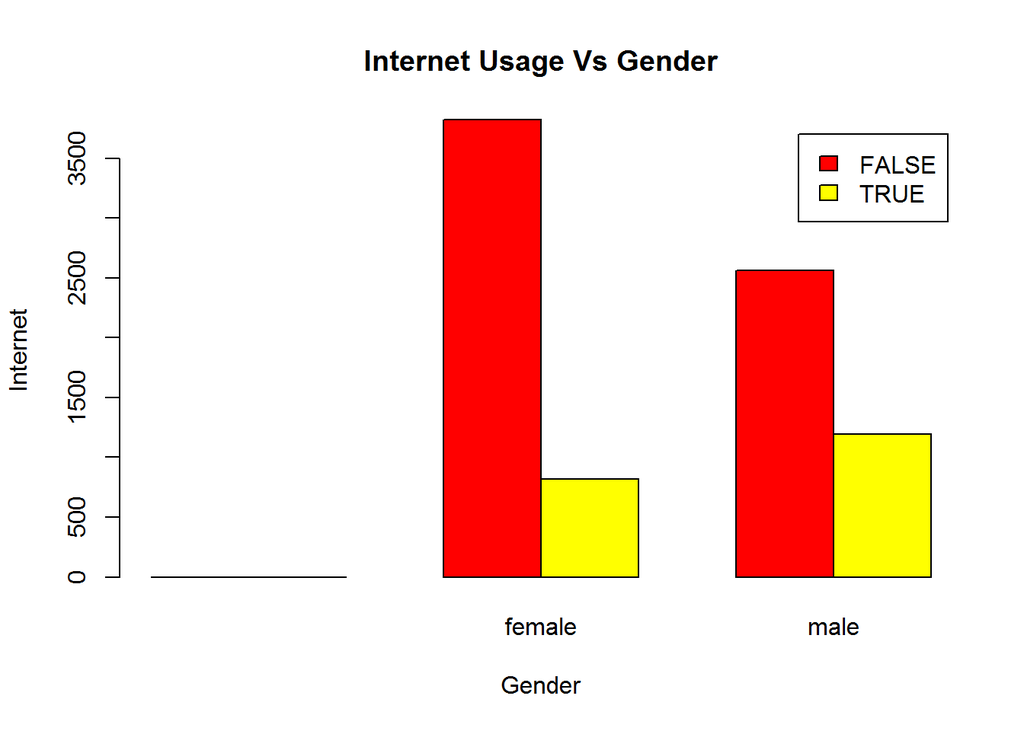

```r
barplot(inter,main="Internet Usage Vs Gender",xlab="Gender", ylab="Internet",col=c("red", "yellow"),legend=rownames(inter), beside=TRUE)
```

```r
#Internet usuage in URBAN
urb<-table(can_use_internet,is_urban)
urb
```

```
##                 is_urban
## can_use_internet FALSE TRUE
##            FALSE  4633 1752
##            TRUE    983 1032
```

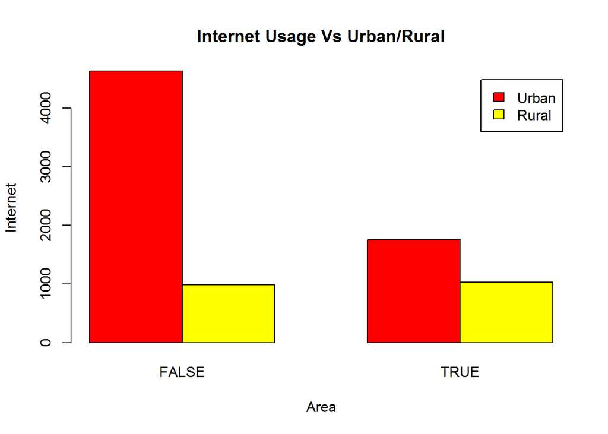

```r
barplot(urb,main="Internet Usage Vs Urban/Rural",xlab="Area", ylab="Internet",col=c("red", "yellow"),legend=c("Urban","Rural"), beside=TRUE)
```

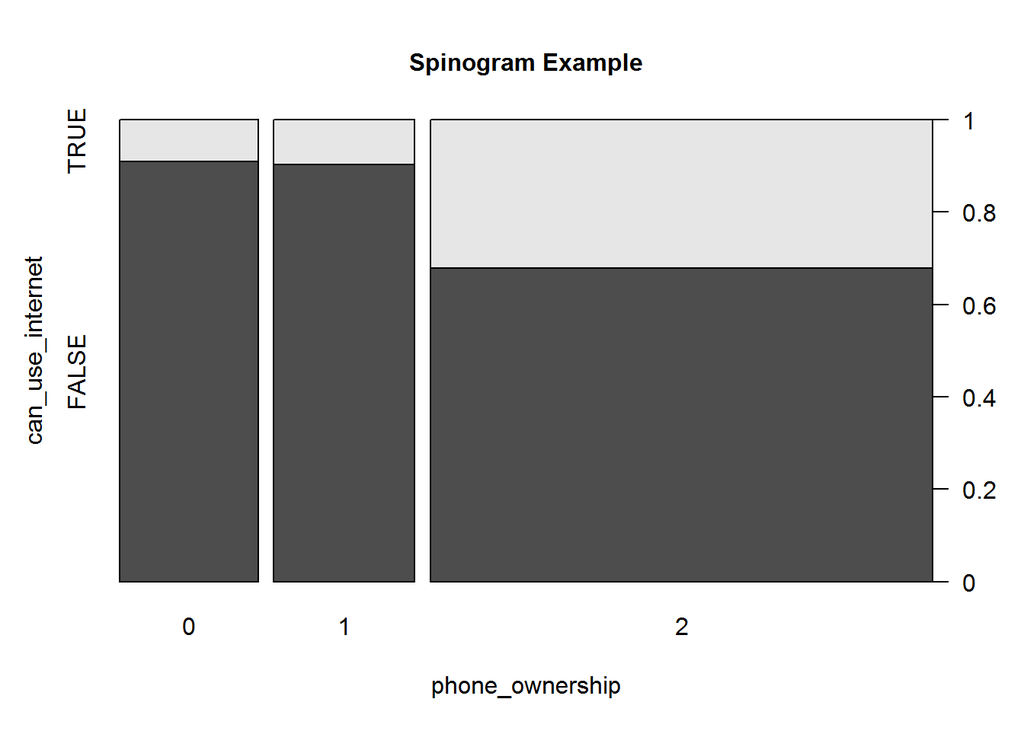

```r
#INTERNET VS PHONE OWNERSHIP
fin<-table(phone_ownership ,can_use_internet)
spine(fin, main="Spinogram Example")
```

#### PIE CHART

female records is 55% more compared to male records which is 45%. The countries A,B,D have more records comapred to other country id

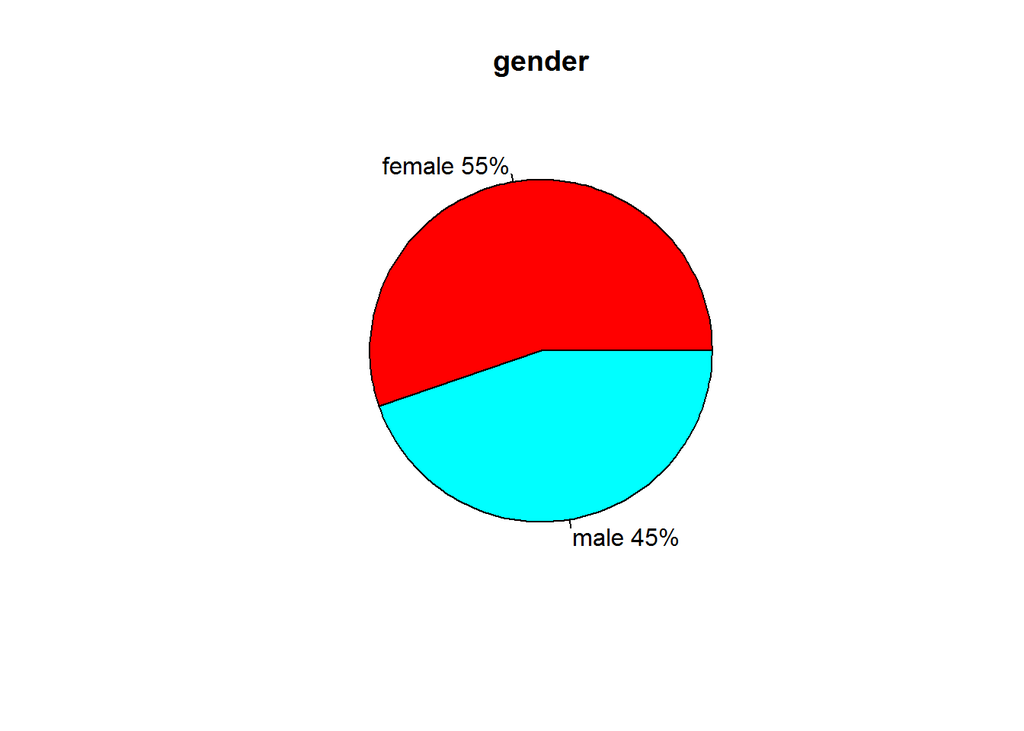

```r
#PIE CHART FOR GENDER
gen<-table(Gender)
slices<-gen[2:3]
lbls<-c("female","male")
pct <- round(slices/sum(slices)*100)
lbls2 <- paste(lbls, " ", pct, "%", sep="")
pie(slices,labels =lbls2 ,main="gender",col=rainbow(length(lbls2)))
```

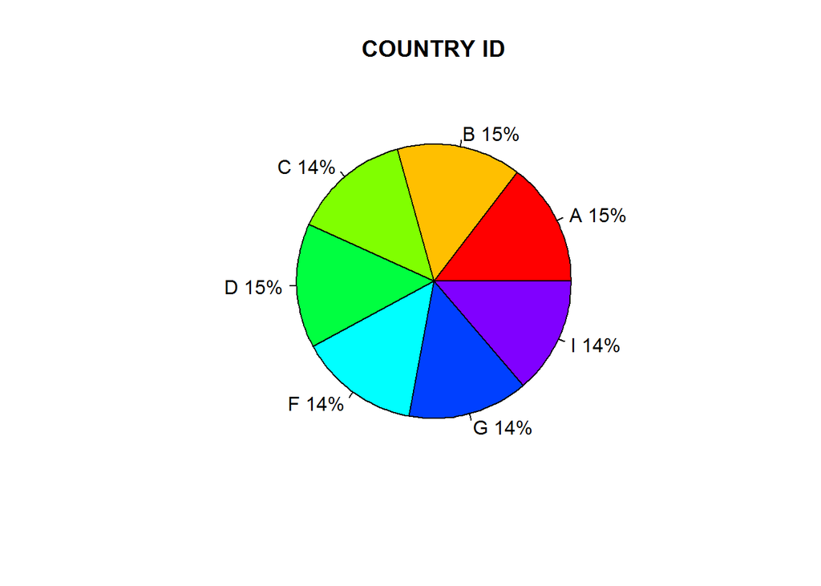

```r
#PIE CHART FOR COUNTRY
con<-table(country_id)
slice<-con[2:8]
lb<-c("A","B","C","D","F","G","I","J")
pct <- round(slice/sum(slice)*100)
lb2 <- paste(lb, " ", pct, "%", sep="")
pie(slice,labels =lb2 ,main="COUNTRY ID",col=rainbow(length(lb2)))
```

#### FAN PLOT & DENSITY PLOT

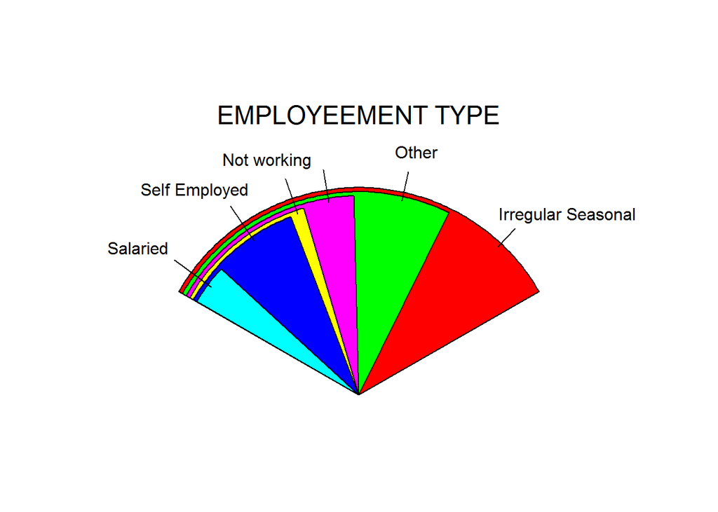

```r
#FAN PLOT
s<-table(employment_type_last_year)
lbls <- c("Irregular Seasonal", "Not working", "Other", "Salaried", "Self Employed")
fan.plot(s, labels = lbls, main="EMPLOYEEMENT TYPE")
```

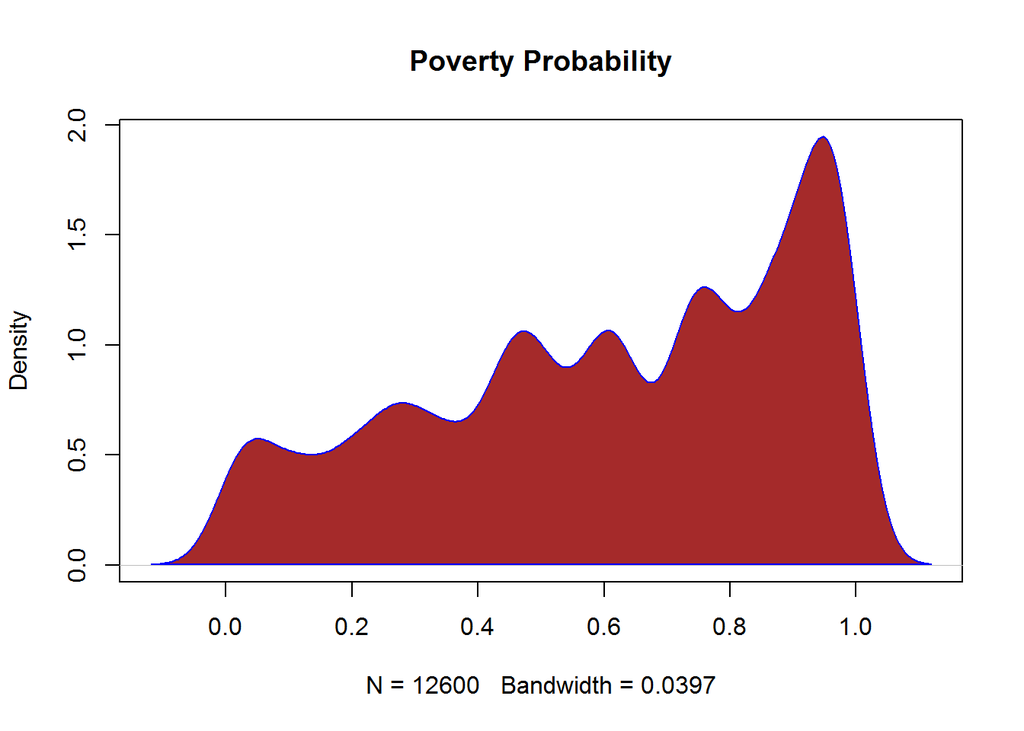

```r
#DENSITY PLOT
d<-density(poverty_probability)
plot(d,main="Poverty Probability")
polygon(d, col="brown", border="blue")
```